# Multiple regression

Ben Whalley

September 2020

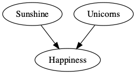

> Multiple regression is a technique which can describe the relationship between *one outcome* and *two or more predictors*.

> We can also use multiple regression to describe cases where two variables *interact*. That is, when the effect of one predictor is increased or decreased by another (this is sometimes called moderation).

> Multiple regression is important because it allows us to make more realistic models and better predictions. But, like any sharp tool, it should be used carefully. If our statistical model doesn’t match the underlying network of causes and effects, or if we have used a biased sample, we can be misled.

> When evaluating our models we can ask two useful questions: First, *how much of the variability in the outcome do my predictors explain?* The $R^2$ statistic answers this. Secondly: *does the model make better predictions than just taking the **average** outcome* (or using a simpler model with fewer predictors)? For this we can compute a Bayes Factor.

# Causal diagrams

Work in pairs to brainstorm what factors influence a phenomena that interests you in applied psychology. If you’re stuck for idea perhaps pick a clinical outcome, or perhaps workplace stress.

1. Start by making a list of all the variables that you think might be important.
2. Draw a causal diagram (using the rules presented in the workshop) of relationships between the variables you identified in the first task. Draw in all the paths where the variables might be related. Leave out paths where you don’t think there is any relationship.
3. Discuss how strong you think each of the relationships (lines) are. What kinds of evidence do you have (or know of) that make you think the diagram is correct?
4. Do some variables have no link between them? If so, discuss whether you think there is really **absolutely no** relationship between these constructs, vs. the case where the relationship is just very weak/uncertain.
5. Can you find examples of *mediation* in your diagram?

Tips for this task:

- You can see an [example drawing in PowerPoint here](https://liveplymouthac-my.sharepoint.com/:p:/g/personal/ben_whalley_plymouth_ac_uk/ETBX6BwhFklJsqYULSb4X2IB6P1kUwXLEYggX407Q2FRHA?e=o7Gfjr). However, use whichever tool feels easiest to you.
- Don’t worry if you have lots of variables, or if your diagram gets very complicated. Just draw in all the connections you think are reasonable.
- Try to leave out some connections if you can. The simpler the set of interconnections the better.

Notice that “Academic performance” has several arrows pointing at it. This shows that this is a model which would enable us to predict academic performance. Your model should also have at least one arrow pointing at “Academic performance”.

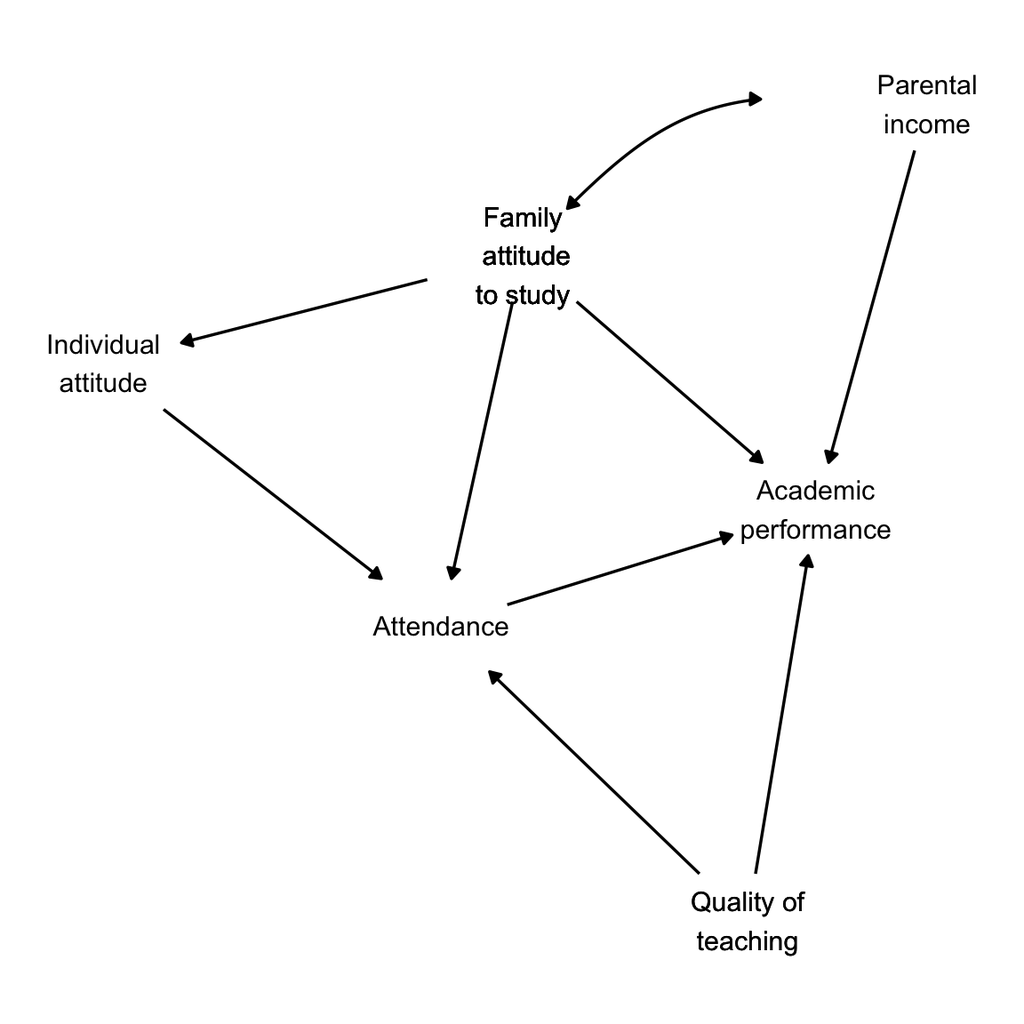

**Can you spot problems with this model? Things you disagree with? Things that might be missing? As an example: should there be additional variables between parental income and academic performance?**

# Testing for Moderation

If you have a hypothesis that a relationship might differ for two different groups, **the first thing you should do is plot the data**.

Before starting, let’s load the tidyverse and the example dataset on student grades and study habits:

```r
library(tidyverse)
studyhabits <- read_csv('https://benwhalley.github.io/rmip/data/studyhabitsandgrades.csv')
```

We know there is a link (in these data) between study hours and grades because we can see it in the plot, and we modeled it using `lm` in a previous worksheet:

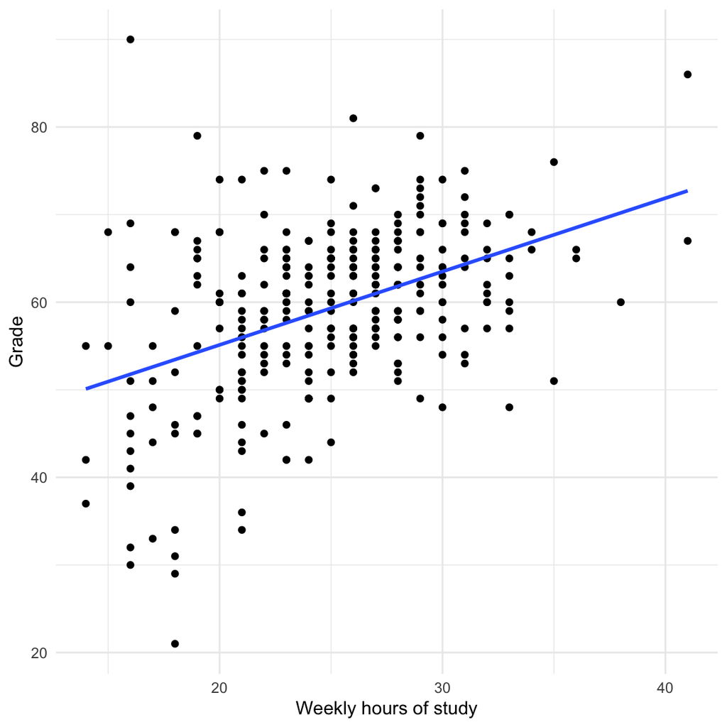

```r
studyhabits %>%
  ggplot(aes(work_hours, grade)) +
  geom_point() +
  geom_smooth(se=F, method=lm) +
  labs(x="Weekly hours of study", y="Grade")
```

We could also ask, is this relationship the same for men and women? To show the differences, we can use a coloured plot:

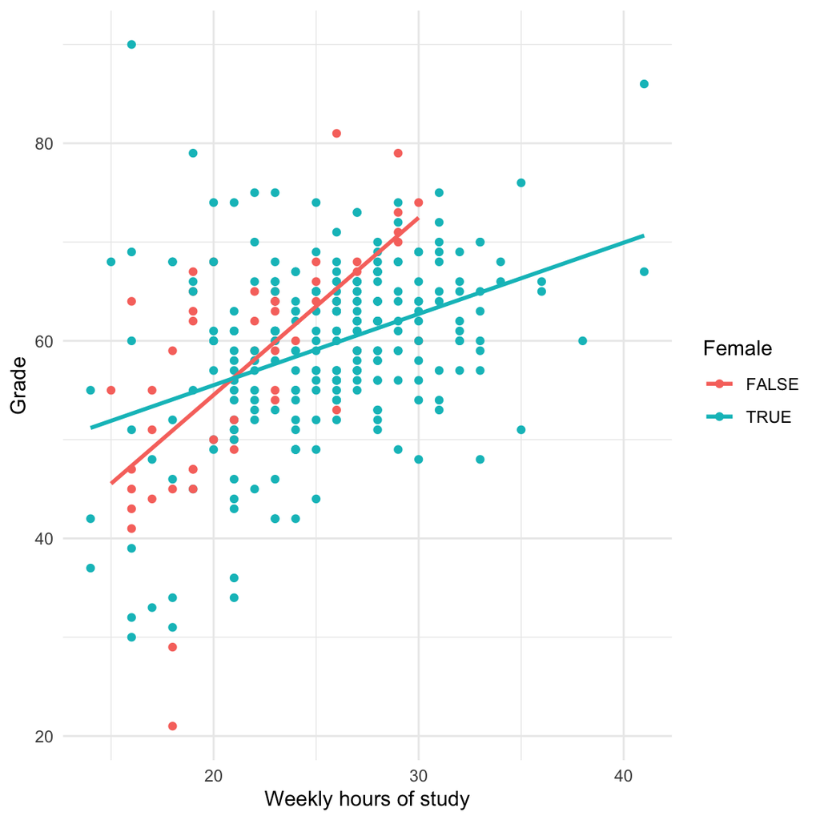

Load the data from `https://benwhalley.github.io/rmip/data/studyhabitsandgrades.csv`

Reproduce the coloured plot from above.

Agree within pairs or groups:

- What is the overall pattern of these simulated results?
- Does extra time spent working benefit men and women equally?
- Do you think it is necessary to have 2 lines in the plot to describe the data, or would fitting a single line for men and women be a reasonable simplification?

# Using `lm` for multiple regression

As we did for single-predictor regression we can use `lm` to calculate numbers to describe the slopes of the lines in our plot.

```r
second.model <- lm(grade ~ work_hours * female, data = studyhabits)
second.model
```

```
##
## Call:
## lm(formula = grade ~ work_hours * female, data = studyhabits)
##
## Coefficients:
##           (Intercept)             work_hours             femaleTRUE
##                18.623                  1.795                 22.463
## work_hours:femaleTRUE
##                -1.074
```

**Explanation of the `lm` code above** This time we have changed the formula and:

- Added `female` as a second predictor
- Used the `*` symbol between them, which allows the slope for `work_hours` to be *different* for men and women.

**Explanation of the `lm` output**: The output looks similar, but this time, we have 4 coefficients:

- `(Intercept)`
- `work_hours`
- `femaleTRUE`
- `work_hours:femaleTRUE`

**Interpreting the coefficients**: The coefficients have changed their meaning from those of model 1. But we can still think of them as either **points** or **slopes** on the graph with fitted lines. Again, I have extended the lines to the left to make things easier:

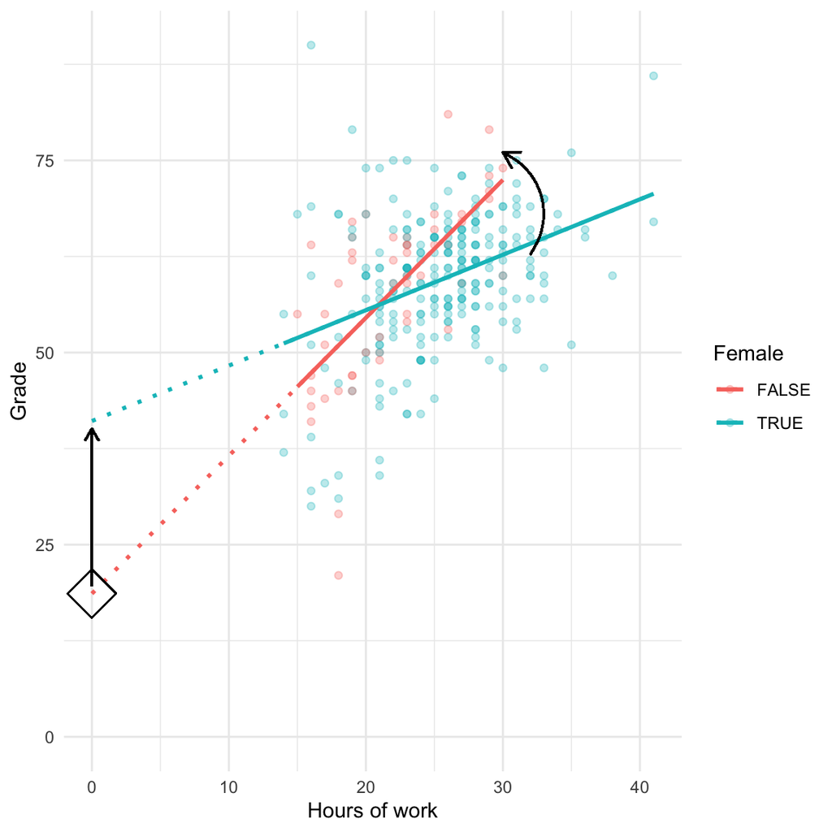

- `(Intercept)` is the point for men, where `work_hours` = 0 (the point marked with a diamond where the red line would cross zero on the x axis).
- `femaleTRUE` is the difference between men and women, when `work_hours` = 0. In the plot this difference marked with an arrow between the blue and red lines, at the zero on the x axis.
- `work_hours` is the slope (relationship) between `work_hours` and `grade` *for men*. In the plot, that is the steepness of the red line.
- `work_hours:femaleTRUE` is the *difference in slopes* for work hours, for women. So to calculate the slope for women we have to add this number to the `work_hours` coefficient which was the slope for men. It’s important to realise that the blue line is the combination of two coefficients; this number tells us the difference between the red and blue slopes, NOT the slope of the blue line.

## Linking coefficients with plots

Compare the model output below with the plot:

```
##
## Call:
## lm(formula = grade ~ work_hours * female, data = studyhabits)
##
## Coefficients:
##           (Intercept)             work_hours             femaleTRUE
##                18.623                  1.795                 22.463
## work_hours:femaleTRUE
##                -1.074
```

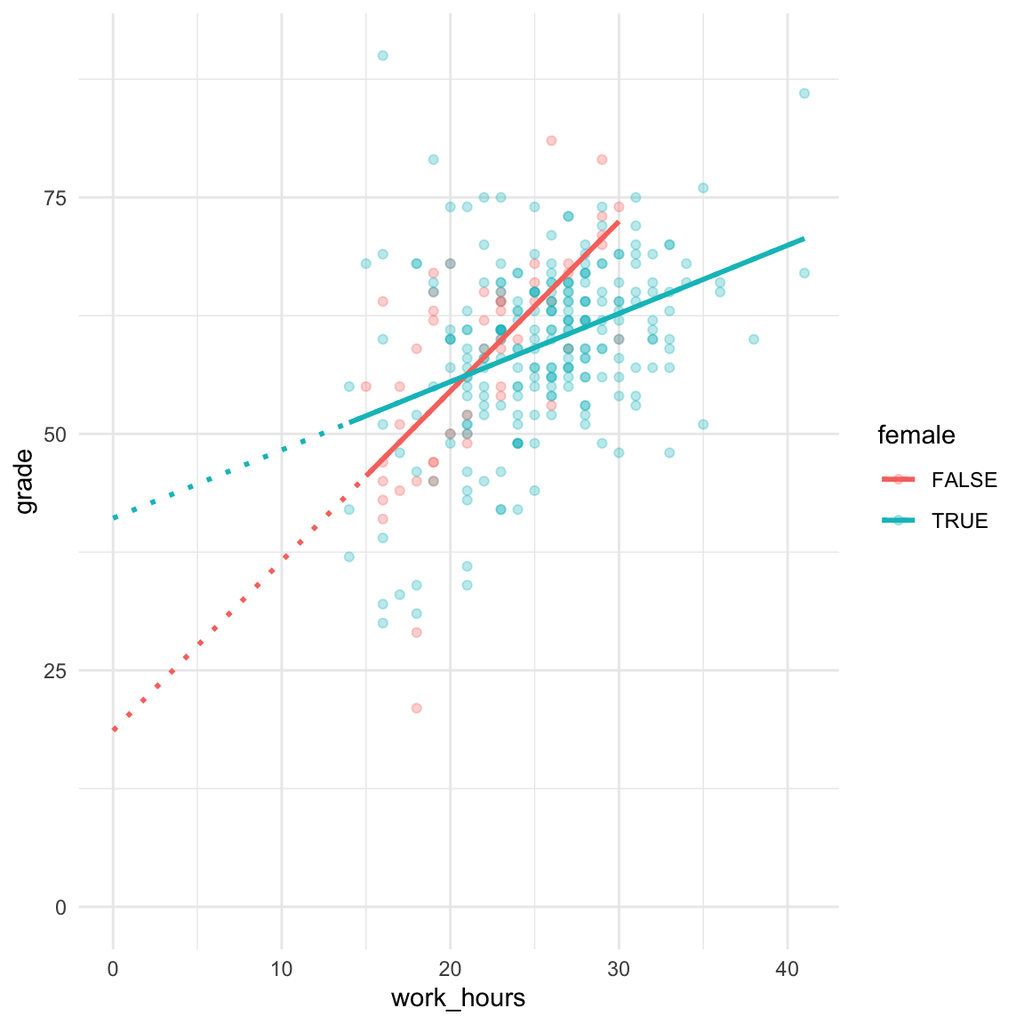

1. For each of the 4 coefficients, decide if it represents a point or a slope
2. Find each of the points on the plot (i.e. which coefficient is it)
3. Compare the slope coefficients to the lines on the plot - can you explain which coefficient describes which slope?
4. What would happen if the sign of each coefficient was reversed? E.g. if one of the coefficients was now a negative number rather than positive? What would this mean for the plot?

Double check you understand how to interpret the `work_hours:femaleTRUE` coefficient. It’s very common for regression coefficients to represent **differences** in this way. But in this example it does mean we have to know both `work_hours` (the slope for men) and `work_hours:femaleTRUE` (the difference in slopes for men and women) to be able to work out the slope for women.

To test your knowledge:

- Calculate the number that describes the slope for women in `second.model` above?

To get the answer we need to add the slope for `work_hours` to the coefficient `work_hours:femaleTRUE`.

- `work_hours` represents the slope for men
- `work_hours:femaleTRUE` represents the difference in slopes between men and women

So the slope for women = $1.7948984 + -1.0735653 = 0.7213331$ (you can round this to 0.721).

# Making predictions from models

As in the previous worksheet we can use `augment` from the `broom` package to make predictions.

The steps are the same:

1. Fit the model we want
2. Load the `broom` package
3. Create a new dataframe with a small number of rows, including only the values of the predictor variables we want predictions for
4. Use `augment` with the model and new dataframe
5. Optionally, we can then plot the results.
1. We have already fitted the model we want to use, which was:

```r
second.model <- lm(formula = grade ~ work_hours * female, studyhabits)
```

2. Next we should load the broom package if we have not already:

```r
library(broom)
```

3. And make a dataframe with values of the predictor variables that would be of interest, or would provide good exemplars.

For example, lets say we want predictions for men and women, who work either 20 or 40 hours each. We can write this out by hand:

```r
newdatatopredict = tibble(
  female=c(TRUE,TRUE, FALSE,FALSE),
  work_hours=c(20,40, 20,40)
)

newdatatopredict
```

```
## # A tibble: 4 x 2
##   female work_hours
##   <lgl>       <dbl>
## 1 TRUE           20
## 2 TRUE           40
## 3 FALSE          20
## 4 FALSE          40
```

Remember that a `tibble` is a special type of dataframe from the tidyverse.

4. The last step is to pass the model and the new data to `augment`:

```r
second.model.predictions <- augment(second.model, newdata=newdatatopredict)
second.model.predictions
```

```
## # A tibble: 4 x 4
##   female work_hours .fitted .se.fit
##   <lgl>       <dbl>   <dbl>   <dbl>
## 1 TRUE           20    55.5   0.821
## 2 TRUE           40    69.9   1.72
## 3 FALSE          20    54.5   1.29
## 4 FALSE          40    90.4   5.19
```

5. Optionally (it’s a good idea) we can plot these new predictions using ggplot:

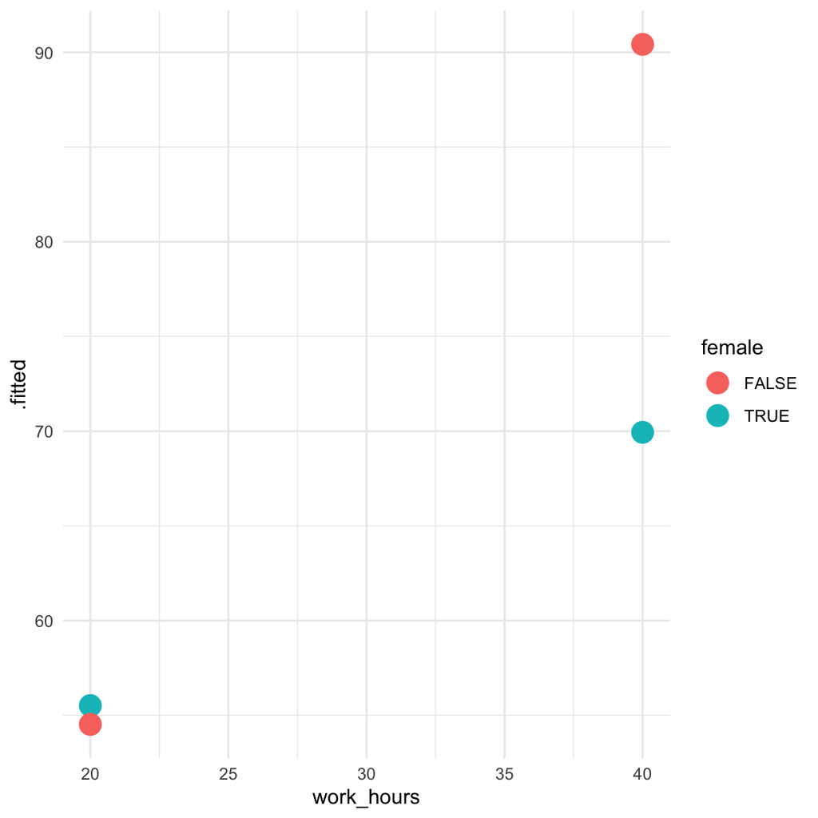

```r
second.model.predictions %>%
  ggplot(aes(work_hours, .fitted, color=female)) +
  geom_point(size=5)
```

Note that the predicted values are in a column called `.fitted`. You need the full stop in `.fitted` - it’s part of the name.

# Plotting predictions

This basic plot we made above is OK, but we can improve it by:

- Joining the points with lines to emphasize the difference in slopes for men v.s. women (remember the gestalt principles we discussed in the data visualisation session?)
- Adding error bars.
- Tidying the axis labels.

To add lines to the plot we can use `geom_line()`. We have to add an additional argument called `group` to the `aes()` section of the plot. This tells `ggplot` which points should be connected by the lines:

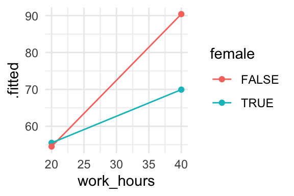

```r
second.model.predictions %>%
  ggplot(aes(work_hours, .fitted, color=female, group=female)) +
  geom_point() +
  geom_line()
```

Next we can add error bars. If we look at the dataframe that `augment` produced, there is a column called `.se.fit`. This is short for **standard error of the predicted value**:

```r
second.model.predictions
```

```
## # A tibble: 4 x 4
##   female work_hours .fitted .se.fit
##   <lgl>       <dbl>   <dbl>   <dbl>
## 1 TRUE           20    55.5   0.821
## 2 TRUE           40    69.9   1.72
## 3 FALSE          20    54.5   1.29
## 4 FALSE          40    90.4   5.19
```

We can use a new `geom_` function with this column to add error bars to the plot.

The `geom_errorbar` function needs two additional bits of information inside the `aes()` section. These are `ymin` and `ymax`, which represent the bottom and top of the error bars, respectively:

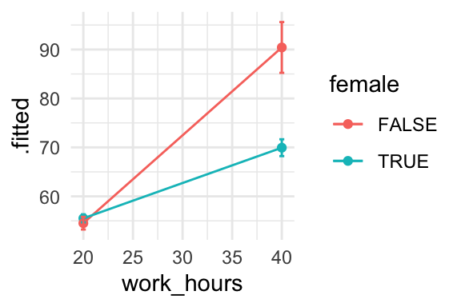

```r
second.model.predictions %>%
  ggplot(aes(
    x=work_hours,
    y=.fitted,
    ymin =.fitted - .se.fit,
    ymax =.fitted + .se.fit,
    color=female,
    group=female)) +
  geom_point() +
  geom_line() +
  geom_errorbar(width=.5)
```

**Explanation of the code**: We added the `geom_errorbar` function to our existing plot. We also added two new arguments to the `aes()` section: `ymin` and `ymax`. We set the `ymin` value to the fitted value, *minus* the standard error of the fitted value (and the same for `ymax`, except we added on the SE).

**Explanation of the resulting plot**: The plot now includes error bars which represent the [standard error](https://en.wikipedia.org/wiki/Standard_error) of the fitted values. We will cover more on intervals, including standard errors, in a later workshop.

In a future session we will cover *intervals* like the standard error and confidence or credible interval in much more detail.

1. Recreate the plot with error bars shown above and tidy up even further by adding axis labels (ggplot has a function called `labs`, which you can add to a plot, e.g. `labs(x="Time", y="Money)`)

# How good is our model?

We can ask two questions about how good our regression models are:

1. How much variance (variability) in the outcome do the predictors explain?
2. How much better are the predictions we make using this model than a simple average?

Make sure you have recently run this code and have model called `second.model` stored.

```r
library(tidyverse)
studyhabits <-  read_csv('data/studyhabitsandgrades.csv')
second.model <- lm(grade ~ work_hours * female, data = studyhabits)
```

## Variance explained

To check what ***proportion of the variance in the outcome the model is explained by our predictors** we can calculate $R^2$.

Note: the ‘R’ in $R^2$ has nothing to do with the R software - it’s the name of the statistic (like a ‘t-test’ or a ‘p value’).

A good way to calculate $R^2$ is with using the `glance` command in the `broom` package. First we need to load `broom`:

```r
library(broom)
```

Then we can use the `glance` function on our regression model (note, if you haven’t just run the model in the current session, you may need to re-run it now):

```r
glance(second.model)
```

```
## # A tibble: 1 x 11
##   r.squared adj.r.squared sigma statistic  p.value    df logLik   AIC   BIC
##       <dbl>         <dbl> <dbl>     <dbl>    <dbl> <int>  <dbl> <dbl> <dbl>
## 1     0.221         0.213  8.49      28.0 5.90e-16     4 -1065. 2141. 2159.
## # … with 2 more variables: deviance <dbl>, df.residual <int>
```

*Explanation of the output*: Glance produces a dataframe of statistics relating to the model. For the moment we only need the one marked `adj.r.squared`. For this model, `adj.r.squared = 0.21`, which means 21% of the variability in `grade` was explained by `work_hours` and `female`.

To report this in APA format, you would say:

> To explain variation in participants’ grades we used multiple regression and included number of working hours, gender, and the interaction of working hours and gender as predictors. This model explained 21% of the variance in grades (adjusted $R^2$ = 0.21).

The `adj.r.squared` value stands for ‘adjusted $R^2$’. This adjustment is done because as you add more predictors to a model it will **always** explain more variability — just by chance. The adjusted value reduces $R^2$ to account for this.

- The gap between regular and adjusted $R^2$ will tend to grow as you add more predictors.
- You should always use `adj.r.squared` in any reports or publications evaluating your model.

## Bayes Factors: The ‘probability of your model’

How do we know it was worth running our model at all? Perhaps our predictors are actually no good, and don’t really help us explain the outcome?

A Bayes Factor can help quantify how likely that is. A Bayes Factor can compare the probabilities of different *hypotheses*, for example:

| **‘No effects’ hypothesis, $H_0$** * | *Experimental hypothesis, $H_1$** |
| --- | --- |
| The predictors **are NOT** related to the outcome (except by chance) | The predictors **are** related to the outcome |

[As you might have seen in the undergraduate teaching materials on t-tests](https://ajwills72.github.io/rminr/evidence.html#bayes-t), you can use the `BayesFactor` package for this type of comparison.

First we load the library and ignore all the warning messages:

```r
library(BayesFactor)
```

Then use the `lmBF` function (instead of `lm`) to re-run our multiple regression model:

```r
lmBF(grade ~ work_hours * female, data = studyhabits)
```

```
## Bayes factor analysis
## --------------
## [1] work_hours * female : 1.084058e+13 ±0%
##
## Against denominator:
##   Intercept only
## ---
## Bayes factor type: BFlinearModel, JZS
```

**Explanation of the command**: We replaced `lm` with the `lmBF` command. This re-ran our regression model and computed a Bayes Factor.

## How to interpret the BF

This means you have very strong evidence that your model is better than no model at all.

Some conventional thresholds and interpretations are:

- BF > 3: Evidence
- BF > 10: Strong Evidence
- BF > 30: Overwhelming evidence

IMPORTANTLY, this only says how much evidence there is that this statistical model is better than *no* model at all. That’s not a very high bar to pass! We’ll talk more about using Bayes Factors dor specific model comparisons later.

SPECIFICALLY: A BF > 3 **doesn’t** prove that your **psychological** model is correct or true. To build a case for that you might want to compare this model with other more complex or ‘reasonable’ alternatives. But that needs to wait for a future session!

If you want, you can refer to these [materials on ‘evidence’ which have more explanation of Bayes Factors](https://ajwills72.github.io/rminr/evidence.html).

## Reporting a Bayes Factor

In this case, you could say something like:

> We found strong evidence that a model including work hours and gender predicted grades (adjusted $R^2$ = 0.21; BF for comparison with the intercept-only model > 1000).

Sometimes, you’ll see Bayes Factor written as BF<sub>**10**</sub>, which means the same thing as BF. You’ll also occasionally see BF<sub>**01**</sub>, which is the same idea but flipped, so BF<sub>01</sub> < 1/3 means substantial evidence for a difference, and BF<sub>01</sub> > 3 means substantial evidence for the null.

1. Use the mtcars dataset and run a `lm` model which predicts `mpg` from `wt` (weight) and `am` (automatic/manual transmission), and allow for a different slope for automatic vs. manual cars.
2. Create a scatter plot with a fitted line on top, (use `geom_point` and `geom_smooth`) which is equivalent to this model.
3. Use `glance` in the `broom` package to calculate the $R^2$ value for this model
4. Use `lmBF` to re-run the same model and calculate the BF for this model. Is it better than no model at all?

```r
# 1
m1 <- lm(mpg ~ wt * am, data=mtcars)
m1
```

```
##
## Call:
## lm(formula = mpg ~ wt * am, data = mtcars)
##
## Coefficients:
## (Intercept)           wt           am        wt:am
##      31.416       -3.786       14.878       -5.298
```

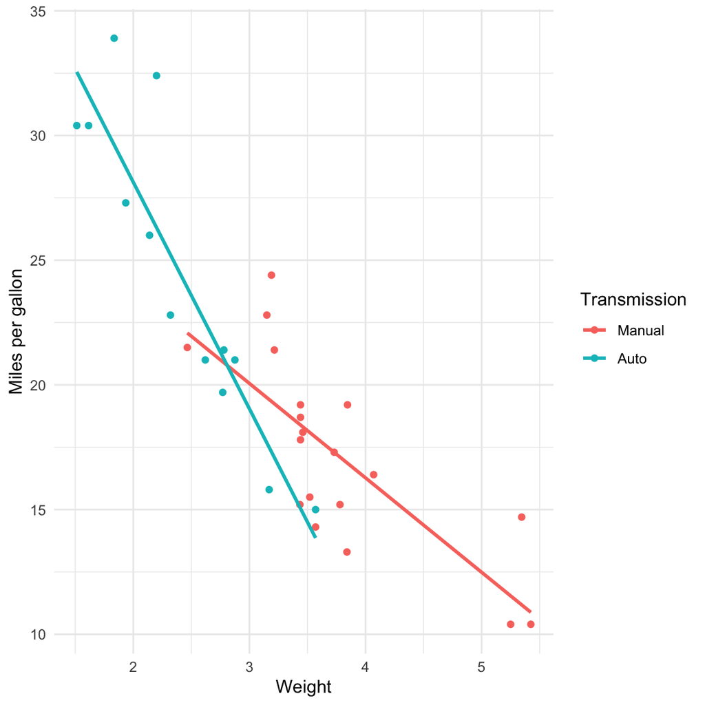

```r
# 2
mtcars %>%
  ggplot(aes(wt, mpg, color=factor(am, labels=c("Manual", "Auto")))) +
  geom_point() +
  geom_smooth(method="lm", se=F) +
  labs(x="Weight", y="Miles per gallon", color="Transmission")
```

```r
# 3
broom::glance(m1) %>% select(r.squared, adj.r.squared )
```

```
## # A tibble: 1 x 2
##   r.squared adj.r.squared
##       <dbl>         <dbl>
## 1     0.833         0.815
```

```r
# 4
library(BayesFactor)
lmBF(mpg ~ wt * am, data=mtcars)
```

```
## Bayes factor analysis
## --------------
## [1] wt * am : 180155786 ±0%
##
## Against denominator:
##   Intercept only
## ---
## Bayes factor type: BFlinearModel, JZS
```

## Testing a specific hypothesis

In the example above we compared our full model to *no model* (that is, a model that just calculates the average grade).

We will often want to run a more specific test of moderation. Do do this we can calculate a BF to compare:

- A model with `female` and `work_hours`, added separately
- A model with `female` and `work_hours`, and where slopes can vary by gender.

If you remember the formlulae for these models were:

- `grade ~ work_hours + female`
- `grade ~ work_hours * female`

The result is a new Bayes Factor for the comparison we are actually interested in.

How to do it:

```r
library(BayesFactor)
A <- lmBF(grade ~ work_hours + female, data=studyhabits)
B <- lmBF(grade ~ work_hours * female, data=studyhabits)

B/A
```

```
## Bayes factor analysis
## --------------
## [1] work_hours * female : 64.24212 ±0%
##
## Against denominator:
##   grade ~ work_hours + female
## ---
## Bayes factor type: BFlinearModel, JZS
```

**Explanation of the output**: We can now see a new BF for the comparison we were interested in: whether a model with varying slopes was more likely to be correct than one with same-slopes for men and women. The BF is roughly 64, which means we have substantial evidence in favour.

1. Try re-running the example from above yourself
2. Try creating another test of moderation and calculate a BF. You could use the `mtcars` data. Remember to include one categorical and one continuous predictor.

# Notes

These are additional explanations or notes for the text above. There are no exercises here.

## Why don’t we always use real data?

Real data is often quite complicated, and it is sometimes easier to simulate data which illustrates a particular teaching point as clearly as possible. It also lets us create multiple examples quickly.

It *is* important to use real data though, and this course includes a mix of both simulated and real data.

## R formulas

In R, **formulas** describe the relationship between variables. They are used widely, e.g. in ggplot, functions like `t.test`, and especially in model-fitting functions like `lm`.

Formulas for regression will always describe the link between one *outcome* and one or more *predictor* variables.

The outcome goes on the left, and predictors go on the right. They are separated by the tilde symbol: the `~`. When you read `~` you can say in your head *“is predicted by”*.

You can add multiple variables by separating them with a `+` symbol. So `outcome ~ age + gender` is a model where the outcome is predicted by age and gender. This doesn’t add interaction terms.

If you want to include interaction terms (e.g. to let slopes vary for different groups) then you use a `*` symbol instead of a plus. So `outcome ~ age * gender` means the outcome is predicted by age, gender, and the interaction of age and gender.

There is a more technical explanation of all of the formula syntax here: https://stat.ethz.ch/R-manual/R-devel/library/stats/html/formula.html

Return to the index page

All content on this site distributed under a [Creative Commons](https://creativecommons.org/) licence. CC-BY-SA 4.0.